# Other Possible TA Duties

There are a few other TA duties that are assigned to 1-3 TAs a semester. TAs with additional duties will have other responsibilities reduced to keep the work distribution fair. So some TAs may have fewer benchmarks to review/write, may not have to monitor the PSY301 TA Team email, or may not have to hold office hours. Below are some of these additional duties.

What you’ll find in this chapter:

- Hype Master (Fall Only)
  - Hype Master Requirements
  - Example Email
  - Standby Option
- Dashboard Runner
  - Dashboard Runner Requirements
  - Dashboard Process
    - Pre-Class Dashboard To-Do List
    - During-Class Dashboard To-Do List
    - Post-Class Dashboard To-Do List
  - Gatekeeper Rules - Opening Gatekeepers - Gatekept Assignments
  - Slack Support

## Hype Master (Fall Only)

Every Thursday in the Fall semester there are live recordings in the LAITS studio in MEZ. A live studio audience is recruited each class period. Having up to 25 students in the audience creates a more lively and enthusiastic experience, and it helps Sam and Paige. Our goal is to have the studio full each lecture. Students really enjoy getting to come visit their professors and see a real TV studio in action. This role is ideal for someone who enjoys interacting with other students - you may score high on extraversion, agreeableness, and conscientiousness. ;)

The studio Hype Master is the person who:

- Welcomes and warms up the audience so they’re excited about the class
- Takes attendance by asking *every* student to sign the sign-in sheet

### Hype Master Requirements

- **Availability**:
  - You must be available to come to the studio in **Mezes every Thursday in the Fall by 3:15 PM**.
  - Stay for the full duration of the lecture until 4:45pm
- **Responsibilities**:
  - Log student attendance in the [Studio Recruitment Log Sheet](https://docs.google.com/spreadsheets/d/1c99r7PZXdpGsK9qJI7nqpL0r9CE9qULdytwzmRFdW9o/edit?usp=sharing)
    - Fill out how many students attended the live class total, and
    - How many, if any, were came into the live recording by being on standby
  - Warm up the audience so they’re excited about the class and excited to be a fun, engaged audience
    - Ask students engaging questions while waiting to be let into the studio
      - “Anyone have any fun weekend plans? Are you going to the game? What classes are you taking?”
      - “What have you thought about the class so far? Are you excited to be in the studio? What made you want to come in?”
      - “What are some of your favorite topics in the class so far?”
  - Pump up the students about how cool the studio and filming experience is
  - Practice clapping and hyping with the audience
  - Have everyone sign the sign in sheet when entering
    - You do have to make sure they do it… sometimes they are shy to ask for the clipboard
  - Remind students of the rules
    - Silence your laptops and your cellphones
    - You are not allowed to leave in the middle of class (unless it is an emergency)
    - No talking or whispering with your fellow classmates during lecture or assignments
      - It is distracting to other students

## Recruiter (Fall Only)

The recruiter is the person to sends out invitations to students to attend the live recordings.

The Recruiter is the person is the person who:

- Sends out invitations to students to attend the live recordings
- Keeps track of who has been emailed
- Updates a datasheet each week

### Recruitment

Recruitment has some level of variability across semesters, as students (and their levels of conscientiousness…) seem to vary. In past semesters, sending ~50 emails was enough to fill 25 spots, while more recently it has taken 100+ emails and the studio may still not completely fill. In addition, some students RSVP but then do not show up.

To better understand these patterns, RAZ will analyze recruitment data (e.g., how many emails were sent, how many students RSVP’d, and how many attended). This ongoing tracking helps us calibrate how wide our email invitations need to go.

We make sure to invite every student at least once during the semester so everyone has the opportunity to see a live class. With our current large invite waves (~50–100+ students), most students will receive multiple invitations over the course of the semester.

**TA responsibilities for recruitment emails:**  
- Send out invitations from the **PSY301 Team** email account.  
- Select students to invite from the **class roster** (which will be shared with you and contains student email addresses).  
- Keep track of which students have already been invited, so that all students have at least one opportunity to attend a live session.  
- Record the details of each recruitment wave in the [**Studio Recruitment Log Sheet**](https://docs.google.com/spreadsheets/d/1c99r7PZXdpGsK9qJI7nqpL0r9CE9qULdytwzmRFdW9o/edit?usp=sharing), including the **email date** and **number of emails sent**. This ensures we can track the full recruitment process alongside RSVP counts and attendance.

### RSVP Logistics

As of Fall 2025, we use Qualtrics to manage studio RSVPs. Each week, the RSVP form caps automatically at 25 students. Once that number is reached, students who click the link will see a message that the session is already full. Those in the first 25 see a confirmation message.

**Week 1 special case:**  
Because we hold two sessions (Tuesday and Thursday) the first week, we use two separate RSVP links:  
- [First Tuesday link](https://utexas.qualtrics.com/jfe/form/SV_1RDMx9U8zFq3oFg?SessionDate=first_tuesday): caps at 25 for the first Tuesday session.  
- [First Thursday link](https://utexas.qualtrics.com/jfe/form/SV_1RDMx9U8zFq3oFg?SessionDate=first_thursday): caps at 25 for the first Thursday session.

**Regular schedule (starting second Thursday):**  
After Week 1, we use a single RSVP link each week:  
- [Studio RSVP Qualtrics Form](https://utexas.qualtrics.com/jfe/form/SV_1RDMx9U8zFq3oFg)

This link automatically resets to allow 25 new sign-ups every Friday at 12:00 am, covering the next Thursday’s studio class. The quota resets itself.

**You should send out your batch of emails on FRIDAYS to recruit for the following week.**

### Data

We track each week’s studio recruitment in the [Studio Recruitment Log Sheet](https://docs.google.com/spreadsheets/d/1c99r7PZXdpGsK9qJI7nqpL0r9CE9qULdytwzmRFdW9o/edit?usp=sharing). The TA responsible for sending the recruitment emails should record the **date emails were sent** and the **number of emails sent**. At the live recording, the in-studio TA (the “Hype Master”) should fill in the **attendance count** and the **recording date** (the Thursday of that session). The **RSVP count** will be logged by RAZ.

#### Standby Option

We offer a “Standby” option to students who want to come, but who were not invited for that particular day. This is only an option if there are seats available. The students who have been invited for that week and responded get priority. Once those are in, we know how many spaces we have left, and we allow in those who have come as standby students. We inform students about the stand-by option when they come into the studio. It is very rare that we have to turn away students due to lack of space. But all this needs to be done early enough so that any students turned away will have time to find another place to watch the class.

### Example Email to Invite Students

**To**: yourself **BCC**: all students invited

**Subject**: PSY 301: Your chance to be part of the magic!

**Greetings from the PSY 301 team!**

As you may know, Sam and Paige record lectures **LIVE** every Thursday from right here on the UT campus. Unfortunately, the studio can hold only about 25 students, so we can only invite a few students for each lecture. But good news, this is YOUR chance to come to the studio, attend a live broadcast, and be part of the magic yourself. We have a slot for you on **[DATE]**.

You’ll get to sit in our professional TV studio in the **Mezes Building (MEZ)** and have an in-person learning experience as you watch Sam and Paige give that day’s lecture. Students in the studio audience play a very important role - they bring energy, support, and enthusiasm that help Paige and Sam perform their best. And sometimes they even get to take part in the class demonstrations!

To make sure we save a seat for you, please complete the Studio RSVP Qualtrics Form so that we know to expect you. Only sign up if you really can come, because if you can’t come we’d like to offer that seat to another student. If you can’t make it this time, don’t worry as we’re hoping to be able to invite you in the future, too.

**Arrival Details**:  
- Arrive no later than **3:15 PM** on the date above.  
- The studio classroom is in **Mezes (MEZ), room 2.206**.  
- **Directions**:  
- Enter the building from the West Main entrance right off the quad.  
- Go up a short flight of stairs.  
- Follow signs for the Liberal Arts Development Studio to the end of the corridor.  
- Wait in line outside the door until a TA comes to get you.

Please don’t respond to this email (unless you have questions) — just fill out the form above if you’re interested. We look forward to seeing you there!

**Best,**  
PSY 301 Team

## Dashboard Runner

The Dashboard, or just “Dash”, is the vital system we use to launch the various activities in the course. It’s the behind-the-scenes setup of all of the moving parts of a lecture class. The dashboard is set up by the course coordinator before each class and then each aspect of the dashboard is deployed at the appropriate time so that students can follow each link (such as a chat or benchmark) away from the lecture stream. The person running the dashboard makes each component visible to the students during live lecture at the appropriate time. Running the dashboard also involves opening “gatekeepers” at the right time (more on this below). Anyone involved in running the dashboard will receive extensive training on this process. The Dashboard Runner is the person who is working “live” to deploy all necessary links and activities. (There may be more than one dashboard runner per semester.)

### Dashboard Runner Requirements

- **Availability**:
  - Fall: Must be available to run the Dashboard on **Tuesdays at 12:30-1:55pm** or **3:15-4:55pm**.
  - Spring: Must be available to run the Dashboard on **Tuesday or Thursday from 3:15-4:55pm**.
- **Experience**:
  - You’ll need to have been a uTA for PSY301 for *at least* one semester before serving as a Dashboard Runner.
- **Checking In 15 Minutes Before**:
  - You’ll need to check in on Slack 15 minutes before class starts to confirm you are online and ready for the broadcast. (This allows others time to find a solution if the Dashboard runner forgets or becomes unavailable.)

### The Dash

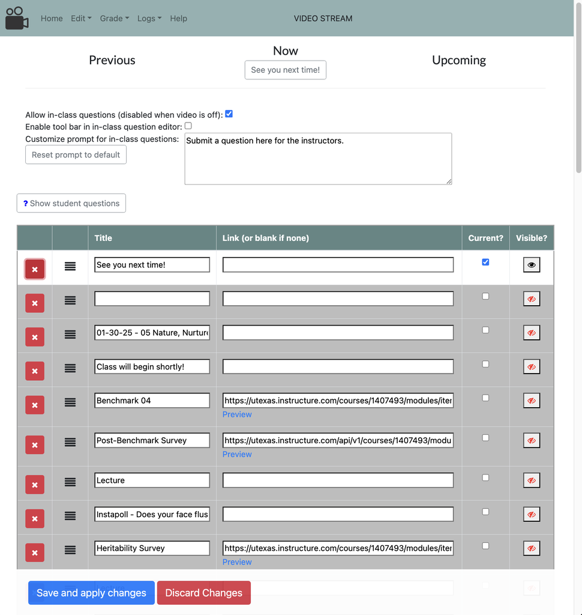

In the Dash we have rows for each part of lecture. (Note there are some blanks spaces or dates that are meant only as notes for the Dashboard runners and are not displayed to the students.)

- Each row has a **Red X** that deletes the row.
- The **three lines (hamburger)** allows you to move the rows around.
- The **“Title”** is what the students will see in the Video Stream.
- The **“Link (or blank if none)”** is where the link to the activity goes.
  - Ex. Title = “Benchmark 04” and the “Link (or blank if none)” = something like the following (please note this is an example link and will not lead you anywhere): “https://utexas.instructure.com/courses/1407493/modules/items/14366833”.
  - The course coordinator will also write notes here for certain activities that do not have a link if need be. For example, Instapolls are *not* shown in the Dash during class. They are only listed in the Dash as a note for the Dash runner. We “launch” the Instapolls from a separate page, more on this below.
- The **“Preview”** button will take you to the linked URL. This is to check and make sure that the link goes to the correct activity.
  - You can click this to take you the assignments that have Gatekeepers. (more on this below)
- The **“Current?”** button is used when we have multiple “revealed” activities (which is rare and only applicable for the RACE lecture IAT activity), so we don’t really have to use it.
- The **“Visible?”** button is a little eye that you can “open” by clicking. This is how you reveal the activity “Title” which appears as a button above the live stream.
  - When students click the button, it takes them to the “Link (or blank if none)”.
  - Every time an item is presented to the students, (by “opening” the eye), the previous eye needs to be “closed.”  
    -For example:
    - Start with “See you next time!” (from previous class)
    - Close that eye, then open the “Class will begin soon!” eye and (very important!) click “Save and apply changes”
- The **“Save and apply changes”** button is vital and must be clicked every time you change something for it to take effect

### Dashboard Process

#### Pre-Class Dashboard To-Do List

1. **Watch the Lecture**:
   - The Dash will be set up for you by the course coordinator. However, you do need to watch the lecture before hand to note roughly the time stamps for when to deploy certain activities.
   - You can also look through the transcripts and use the Find option to figure out roughly when certain activities will be launched.
2. **Set Up Workspace**:
   - To get to the Dash, navigate to the “Video Stream” tab in Canvas (upper left).

#### During-Class Dashboard To-Do List

1. **Launch Activities**:
   - First activity is always Benchmark #. Always update gatekeeper(s) to “Start Now” when Sam/Paige say “It’s benchmark time.” BEFORE making the benchmark available in the dashboard.
     - Note the gatekeeper timer is set to add *an addition minute* to account for any server delays/timing issues.
   - Change current activity as Sam/Paige transition by clicking the little Eye on the right and then save. (The Eye reveals the items.)
2. **Instapolls**:
   - For chats: Launch the Instapoll in the chat once Sam/Paige says, “Wrap up your chat.”
   - For non-chat polls: Send them when instructed by Sam/Paige.
   - **NOTE: Instapolls are written in the Dashboard list, but we DO NOT show this in the Dashboard. These serves as notes for the Dashboard Runner to know when an Instapoll is coming. You launch them from the Instapoll page. See below.**

#### Post-Class Dashboard To-Do List

1. **Wrap Up Dashboard**:
   - Change the dashboard message to “See you next time!” after RAS (5 minutes).
2. **Clean Up Dashboard**:
   - Once class is over, please delete all of that day’s activities by clicking the little red X. Save the changes.

#### Notes in the Dash

Most of the objects in the Dashboard are meant to be displayed to the students. However, to make it more organized and annotated, the Dash also has other notes in there. For example, every lecture, date, and lecture number are included as are Instapolls with a note on what the poll is asking. There are two examples of something that are NOT meant to be displayed to students. They are purely to help the Dashboard Runner. ;)

#### Navigating to the Dashboard

**To get to the Dashboard, Click Edit -> Edit Page**

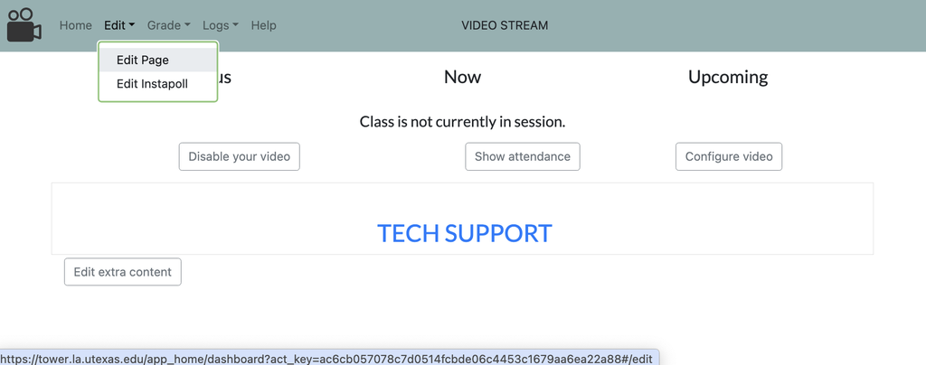

#### Desktop View when Running the Dash

Here is example of you desktop view when running the Dash with the Student View (Video Stream), Dashboard Editor Page, and the Instapolls page. (Another computer monitor would be a great way to organize all these windows…)

[figure not shown]

### Gatekeeping

We use something called Gatekeeping to make sure students don’t have access to certain materials beforehand. Gatekeepers are set by the course coordinator in advance. The Dashboard Runner opens (releases the gatekeeper for) the assignments.

#### Opening Gatekeepers

1. From the Dashboard, copy paste the URL for the Benchmarks and RASs into your browser or click the “Preview” button. This will take you to the particular assignment.
2. In the upper left, click the drop down “Edit”.

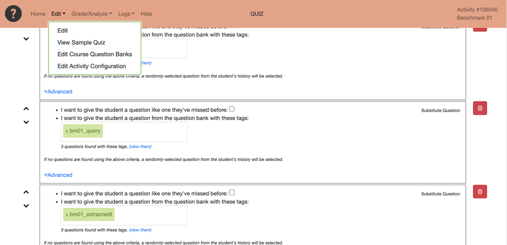

3. Click on “Edit Activity Configuration”.
4. When it is time to launch the assignment, click the (teeny tiny) “Start Now” check box and click “Save.” (Sometimes this takes a few seconds… We add an extra minute to the time we give the students to account for this.) This is also why you first make sure to release the gatekeeper THEN reveal the activity in the Dash– clicking the little Eye and hitting “Save”. It takes some getting used to, but you will learn how much earlier you need to release the gatekeeper so that it saves and is ready to be revealed to the student right after Sam or Paige say “It’s benchmark time!”

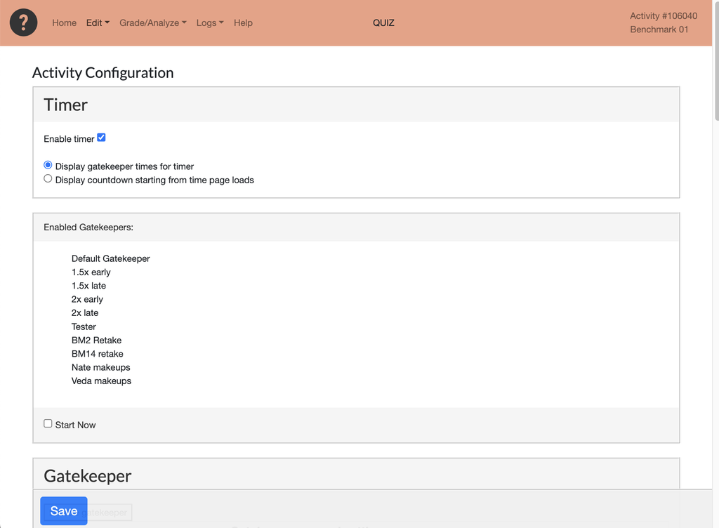

Release Assignment with “Start Now”

#### Gatekept Assignments

- **Benchmarks**
- **RASs**

### Instapolls

Instapolls are one of the class activities that require launching from the Instapoll page when Sam and Paige say something like “You should be seeing an Instapoll now.” To launch the polls, navigate to the Video Stream from Canvas. Once in the Video Stream go to Edit -> Edit Instapoll.

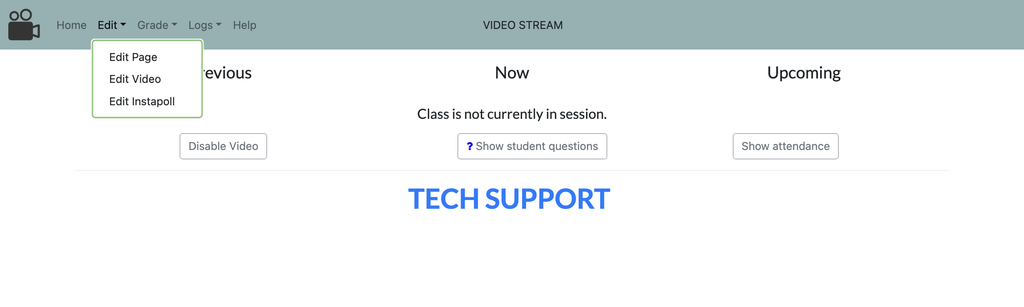

You will see all the Instapolls for the semester here. They are organized with the first Instapolls at the end and the last Instapolls at the top. (I do not know why…) You’ll navigate to the Instapolls launching that day. You can check this by reviewing the Dashboard page. The course coordinator will leave notes about which Instapolls are being launched. Once Sam and Paige mention the Instapoll, hit “Send Now”. And that’s it! If there are more Instapolls to launch for that class, leave the page open, otherwise you can close it.

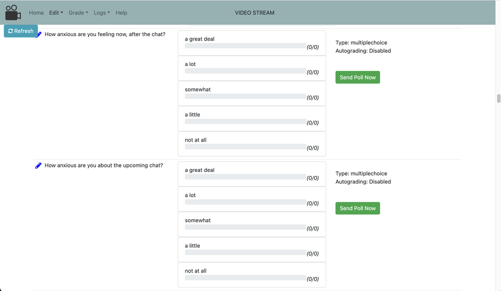

Launching Instapolls

### Slack Support

And lastly, since this is such a big class and we need it to run smoothly, we have our own dedicated LAITS studio person to help us! Anytime you run the dashboard, you will not be alone! You will be on Slack in the #class-time channel (This one is locked to only those who need access.) with one of our LAITS super project managers who will be testing everything as you launch and will help with any troubleshooting. ;)